# Rougheye Rockfish

*Sebastes aleutianus*

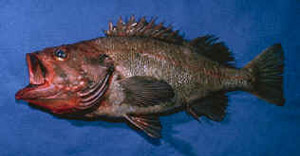

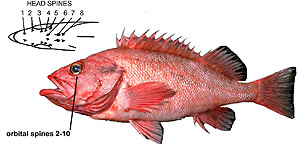

**Body color:** Red on back, becoming pink on sides, often w/ vague spots and traces of dusky bars; fins reddish, w/ black on tips; inside of mouth red-black to red-white; posterior part of lateral line often light. (See occasional dark phase in above photo.)

**Peritoneum color:** light w/ dots **Shape between eyes:** convex to flat

**Counts:** D:XIII-XIV,12-15, Ar:6-8, P1:17-19, GR:29-35, LLp:29-37, LLs:47-55, V:27

**Occurence:** Bering Sea - Southern California

**Depth:** 100-600 meters **Size:** 97 cm **Species code:** 30051

**Similar species:**

- *Shortraker rockfish* - 0 or rarely 1 eye spine; body pink to orange-pink, typically w/out dark color on body; specimens >40 cm w/ gillrakers on first arch 3 times longer than width (5-6 times in Rougheye RF); head spine 6 typically absent
- *Blackgill rockfish* - 0 or rarely 1 eye spine; head spine 6 typically absent; mouth, upper branchiostegal membranes, and gill cavity black
- *Pacific Ocean Perch* - head spines weak and differ in count; discrete dark blotches at base of dorsal fin; symphyseal knob prominent
- *Sharpchin rockfish* - discrete dorsal blotches w/ at least one crossing lateral line; prominent symphyseal knob; head spines differ in count; anal spine 2 longer than 3
- *Yelloweye rockfish* - body bright yellow-orange (reddish in young <28 cm); head spines rugose w/ multiple points and count differs

Back to Group

**Corrections:** If you see mistakes or want to suggest changes, please create an [issue](https://github.com/zoyafuso-NOAA/RACE_Survey_App/issues) on the source repository or

*reach out to Liz Dawson (Liz.Dawson AT noaa.gov).*